# A3: Incarceration

### Introduction

The issue of mass incarceration in the United States poses significant social and policy challenges. This analysis examines key variables to understand trends and disparities in prison populations. I focus on the total prison population over time in Washington State’s top counties, gender disparities in incarceration rates in the top nine states, and the geographical distribution of prison populations across all states. These variables reveal important patterns, such as regional and gender-based disparities, helping inform policies aimed at reducing incarceration rates and addressing underlying causes. Our goal is to provide insights that contribute to more effective and equitable criminal justice policies.

### Summary Information

In the summary, at first, I am trying to calculate the average total prison population across the US from 1970 to 2018, and which is 361. Secondly, I would like to figure out what is the county with the highest total prison population through all time, which is Los Angeles County in 2007 with 58068 prison population. Thirdly, the lowest prison population county is Alpine County in 1983. Fourth, the county with the highest black prison population is New York County in 1998 with population 24818. Last, the county with the highest male prison population is Los Angeles County in 2007 with male prison population 54365.

### The Dataset

Who collected the data? Vera Institute of Justice.

How was the data collected or generated? The data was collected through the Census of Jails, the Annual Survey of Jails, and the National Corrections Reporting Program, through surveys and records.

Why was the data collected?  
The US prison population data was collected to provide an understanding of incarceration trends across the country. The goals were to analyze the growth and disparities in jail and prison populations, inform public policy, and guide reforms in the justice system.

How many observations (rows) are in your data?

```r
num_rows <- nrow(data)
print(num_rows)
```

```
## [1] 153811
```

How many features (columns) are in the data?

```r
num_columns <- ncol(data)
print(num_columns)
```

```
## [1] 36
```

What, if any, ethical questions or questions of power do you need to consider when working with this data?  
Ethical considerations include privacy and confidentiality, addressing potential biases and injustices. We need to consider all variables including regions and races fairly through processing.

What are possible limitations or problems with this data? (at least 200 words) The US prison population data has several limitations and potential problems. Firstly, the accuracy and completeness of the data can be compromised due to reporting errors or inconsistencies across different sources. Not all jurisdictions may report data uniformly, leading to gaps and discrepancies that can affect the reliability of the analysis. Additionally, the dataset may reflect systemic biases inherent in the justice system, such as racial disparities, which could influence the interpretation of the data. The integration of multiple sources, like the Census of Jails, the Annual Survey of Jails, and the National Corrections Reporting Program, while comprehensive, may also introduce challenges in standardizing and reconciling data from different methodologies and definitions. Furthermore, there may be ethical concerns regarding the use of data without informed consent from the individuals represented, raising questions about privacy and confidentiality. Researchers must be mindful of these limitations and strive for transparency and accountability in their work, ensuring that their findings are used to promote justice and equity rather than perpetuate harm. Addressing these limitations requires critical analysis, rigorous data validation, and a commitment to ethical standards.

### Trends Over Time Chart

[figure not shown]

### Variable Comparison Chart

My second chart is a comparison of the female and male prison populations across the top nine states. This chart helps me analyze the gender disparities in incarceration within these states. According to the plot, I can conclude that the male prison population is significantly higher than the female prison population in all top states. California and Texas have the highest total prison populations, with a substantial difference between male and female inmates. This pattern is consistent across other states. The chart highlights the stark contrast in incarceration rates between genders.

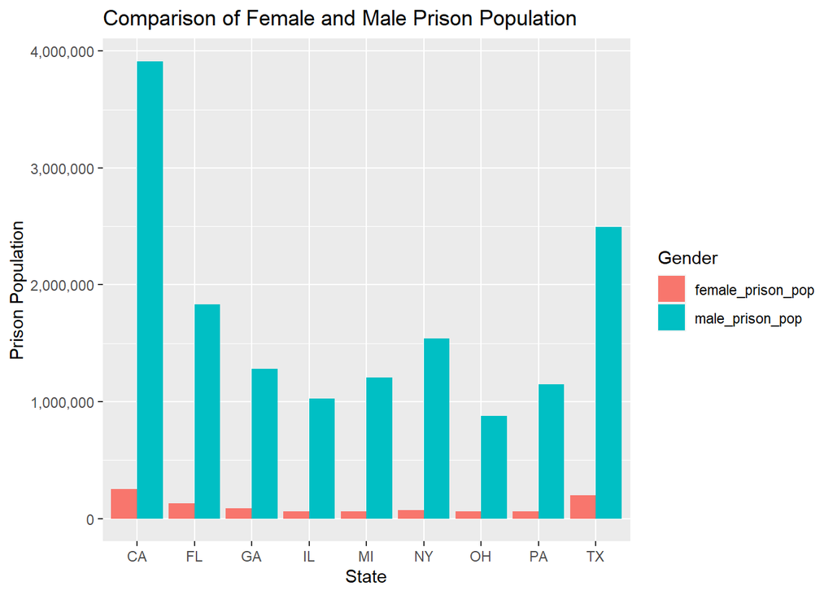

### Map

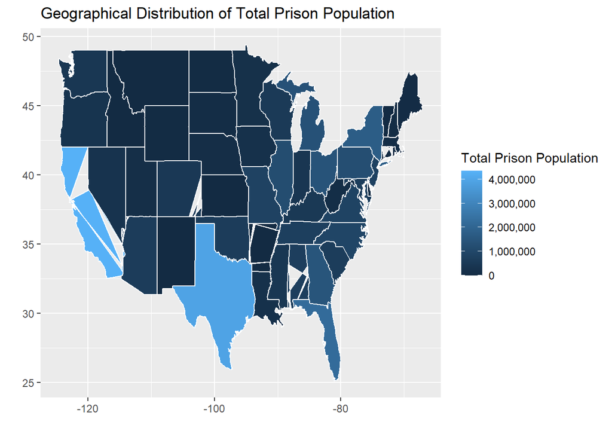